# KFS Parameter Initialization

Ewok

October 18, 2016

## Pseudocode

### Input

y - m x t, observations/measurements

### Output

A - n x n, state transition matrix  
C - m x n, observation model matrix  
Q - n x n, environmental noise  
R - m x m, measurement noise  
x0 - n x 1, initial state estimate  
v0 - n x n, initial covariance estimate

### Function Names

KFS_init - initializes the parameters for the Kalman Filter/Smoother

### Instructions

Read the paper found [here](http://numbat.ucsd.edu/~bob/estimation/Estimation_Fall_2010/Notes_and_docs_files/P61_Barb_TSP.pdf) for better understanding of importance of initial noise estimates.

We will initialize the state estimate to be the first measurement given by the input y, because this is simplest estimate. We will initialize the covariance estimate to the zero matrix, because v0 is less crucial to the outcome of the KFS than Q and R, and is typically an underestimate. The choice of R is less important than Q, as it has more of an impact on the variation of the state estimates. We will initialize R to the identity matrix. Too small an estimate for Q leads to overconfidence in the predicted state, while too large an estimate leads to oversensitivity to noise. Q determines the amount of weight given to the Kalman gain. We will initialize Q to the identity matrix times the estimated mean squared error per dimension, like so:
$$Q = \begin{bmatrix}
\frac{1}{T}\sum_{t=1}^{T-2}\left(y_{1,t+1}-\frac{y_{1,t}+y_{1,t+2}}{2}\right)^2 & 0 & \dots & 0 \\
0 & \frac{1}{T}\sum_{t=1}^{T-2}\left(y_{2,t+1}-\frac{y_{2,t}+y_{2,t+2}}{2}\right)^2 & \dots & 0 \\
\vdots & \vdots & \ddots & \vdots \\
0 & 0 & \dots & \frac{1}{T}\sum_{t=1}^{T-2}\left(y_{n,t+1}-\frac{y_{n,t}+y_{n,t+2}}{2}\right)^2
\end{bmatrix}$$
Given no information about the system, we will assume the state variables are independent and linear, thus initializing A to the identity matrix. We will assume C is a diagonal matrix of 1s (not necessarily square).

## Simulation Description

### Example showing good performance (Sim. 1)

Simulate two sinusoidal waves offset by some amount, adding normally distributed noise. Use KFS_init to initialize parameters based on the measurement values. Generate uniformly random matrices for A,C,Q,R that have values between 0 and 1. For x0 and v0 generate properly sized matrices that have values between -1 and 1 (adding the offset for x0[2]). We expect to see a higher correlation coefficient for the parameter initialized Kalman Filter and Smoother than the randomly initialized Kalman Filter and Smoother.

### Example showing poor performance (Sim. 2)

Similar process for example showing good performance, but increase the normally distributed noise by a factor of 10.

## Evaluating Performance

To evaluate the performance of the parameter initialization, we will compare the resulting KFS values to the KFS values resulting from a random initialization. We will qualitatively evaluate the performance by two plots of three curves each:  
1) Actual sinusoids, random Kalman Filtered values, parameter initialized Kalman Filtered values  
2) Actual sinusoids, random Kalman Smoothed values, parameter initialized Kalman Smoothed values  
We will hide the measurement noise for visual clarity.

To quantitatively evaluate the performance, we will examine the correlation coefficent $R^2$ values. The filtered and smoothed $R^2$ values for the parameter initialization should be higher than the random initialization.

## Algorithm Code

```r
KFS_init <- function(y) {
  n = dim(y)[1]
  t = dim(y)[2]
  A <- diag(n)
  C <- diag(n)
  R <- diag(n)
  sum = array(0, dim=c(1,n))
  for(d in 1:n) {
    for(i in 1:(t-2)) {
      sum[d] = sum[d] + (y[d,i+1]-((y[d,i]+y[d,i+2])/2))^2
    }
  }
  msqe = sum/t
  Q <- diag(as.vector(msqe))
  x0 <- y[,1]
  v0 <- diag(n)*0
  return(list(A=A, C=C, Q=Q, R=R, x0=x0, v0=v0))
}
```

## Simulation Code

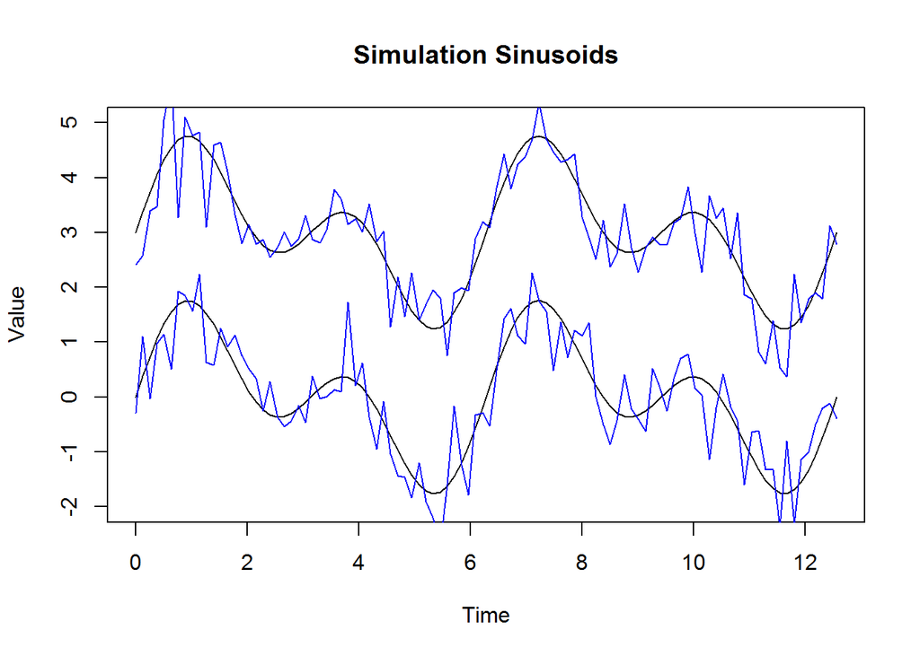

```r
t <- seq(0,4*pi,,100)

actual1 <- sin(t) + sin(2*t)
actual2 <- sin(t) + sin(2*t) + 3
actual = array(actual1, dim=c(100,2))
actual[,2] <- actual2

meas1 <- actual1 + rnorm(100, mean=0, sd=0.5)
meas2 <- actual2 + rnorm(100, mean=0, sd=0.5)
meas = array(meas1, dim=c(100,2))
meas[,2] <- meas2

plot(t, actual[,1], type="l", main="Simulation Sinusoids", xlab="Time", ylab="Value", ylim=c(-2,5))
lines(t, actual[,2], col="black")
lines(t, meas[,1], col="blue")
lines(t, meas[,2], col="blue")
```

## Simulate and Evaluate

We will perform and evaluate each simulation ten times to demonstrate the consistency of the results.

### Sim. 1

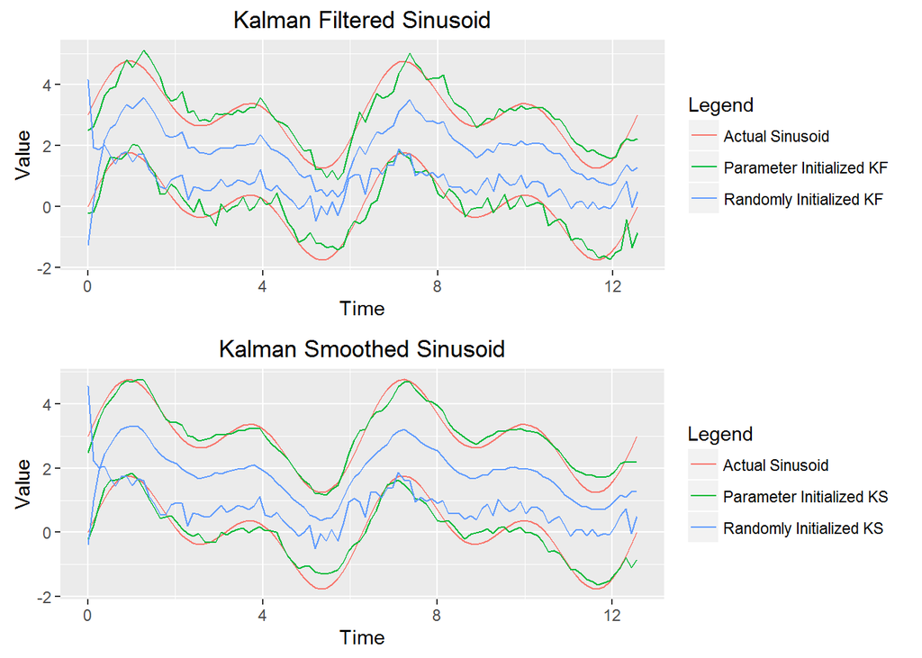

```
## [1] "Measurement R^2:  0.75022 0.8159"
## [1] "Kalman Filter R^2:  0.88643 0.8632  vs.  0.70323 0.53584"
## [1] "Kalman Smoother R^2:  0.93208 0.94653  vs.  0.86121 0.4944"
```

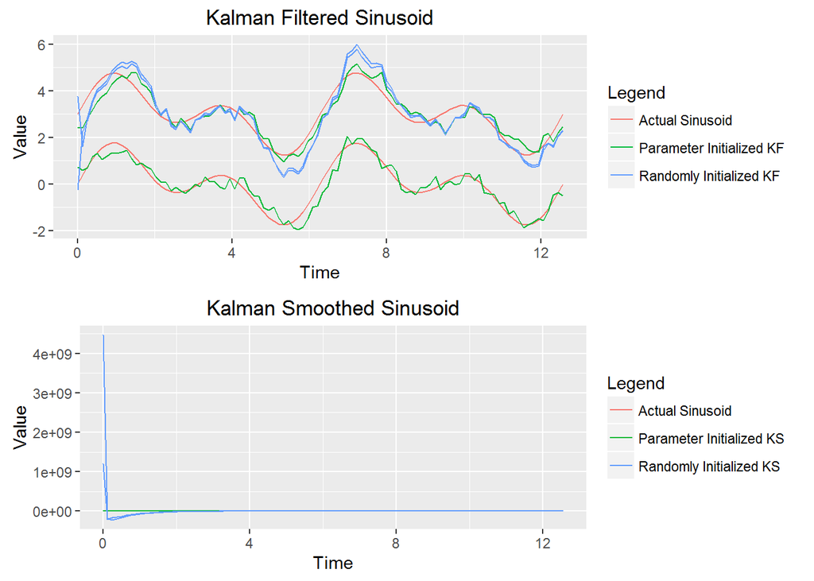

```
## [1] "Measurement R^2:  0.79866 0.80586"
## [1] "Kalman Filter R^2:  0.9066 0.83385  vs.  0.82839 0.86749"
## [1] "Kalman Smoother R^2:  0.95225 0.93851  vs.  0.00133 0.01173"
```

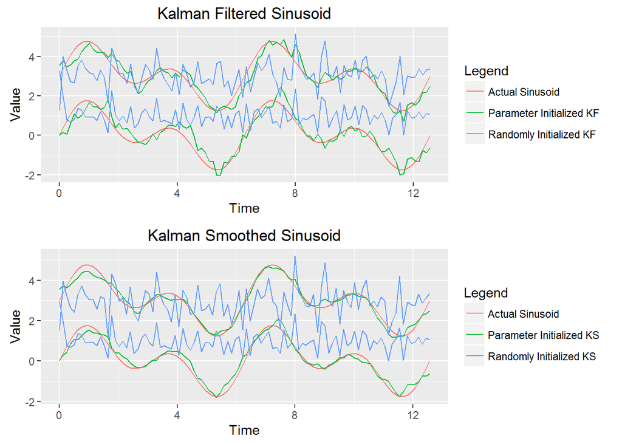

```
## [1] "Measurement R^2:  0.77421 0.80439"
## [1] "Kalman Filter R^2:  0.87192 0.8826  vs.  0.031 0.00432"
## [1] "Kalman Smoother R^2:  0.95364 0.95921  vs.  0.02293 0.00463"
```

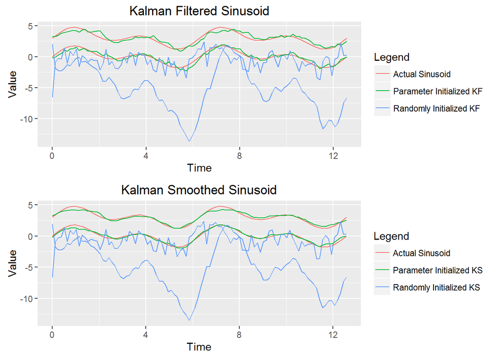

```
## [1] "Measurement R^2:  0.8014 0.78586"
## [1] "Kalman Filter R^2:  0.8893 0.83069  vs.  0.71579 0.18766"
## [1] "Kalman Smoother R^2:  0.95917 0.93902  vs.  0.74193 0.19225"
```

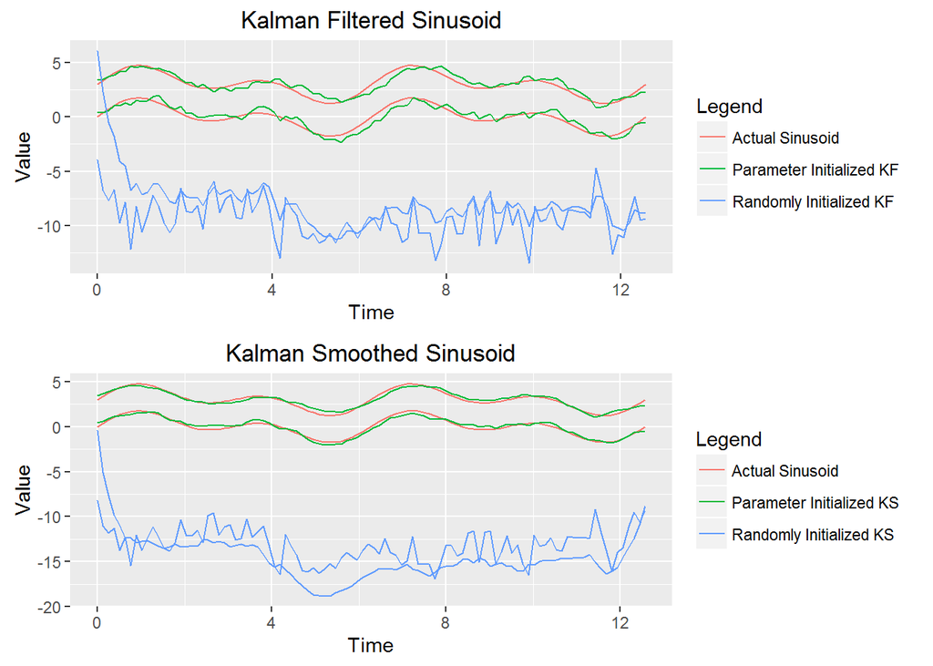

```
## [1] "Measurement R^2:  0.77461 0.80704"
## [1] "Kalman Filter R^2:  0.84328 0.84403  vs.  0.00033 0.133"
## [1] "Kalman Smoother R^2:  0.93159 0.94269  vs.  0.00017 0.10516"
```

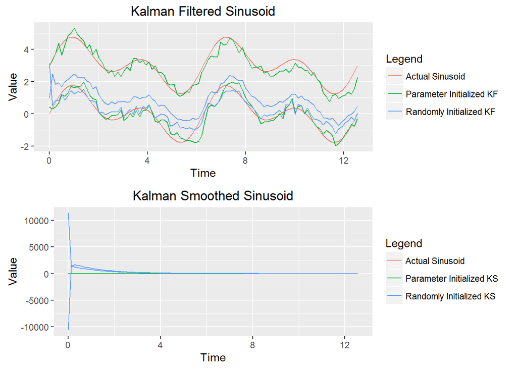

```
## [1] "Measurement R^2:  0.79444 0.81464"
## [1] "Kalman Filter R^2:  0.86391 0.9059  vs.  0.89178 0.74095"
## [1] "Kalman Smoother R^2:  0.95586 0.9478  vs.  0.02275 0.01452"
```

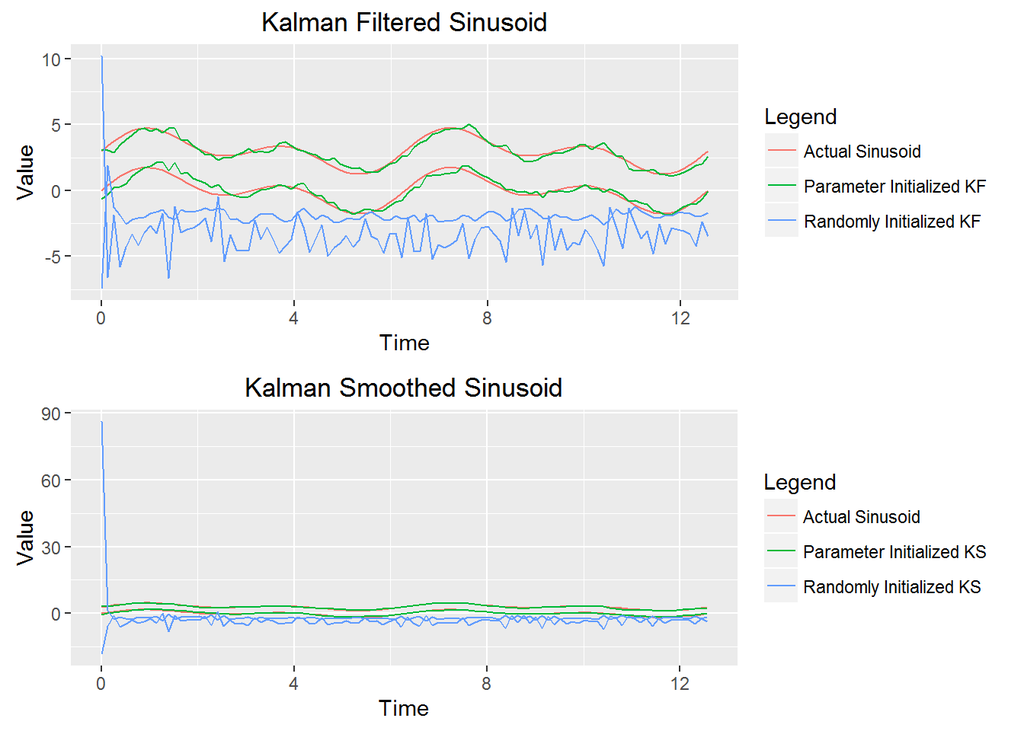

```
## [1] "Measurement R^2:  0.83774 0.82304"
## [1] "Kalman Filter R^2:  0.8781 0.91682  vs.  0.00191 0.00096"
## [1] "Kalman Smoother R^2:  0.95711 0.96613  vs.  0.00136 0"
```

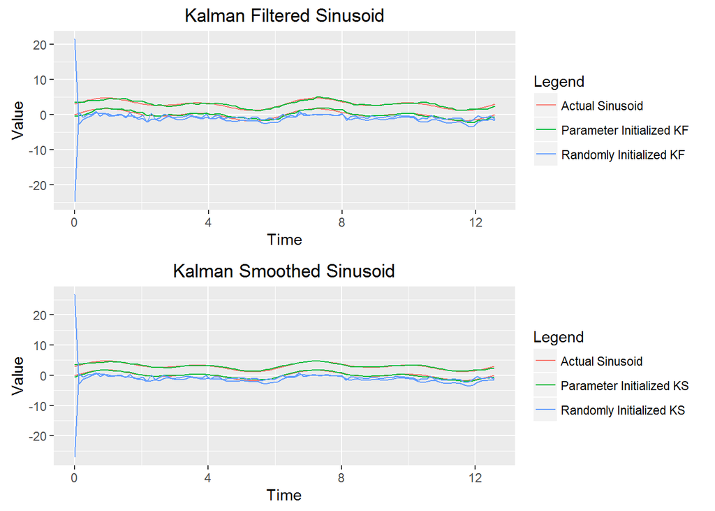

```
## [1] "Measurement R^2:  0.83726 0.83782"
## [1] "Kalman Filter R^2:  0.8896 0.89165  vs.  0.01998 0.08665"
## [1] "Kalman Smoother R^2:  0.95473 0.96817  vs.  0.02573 0.07395"
```

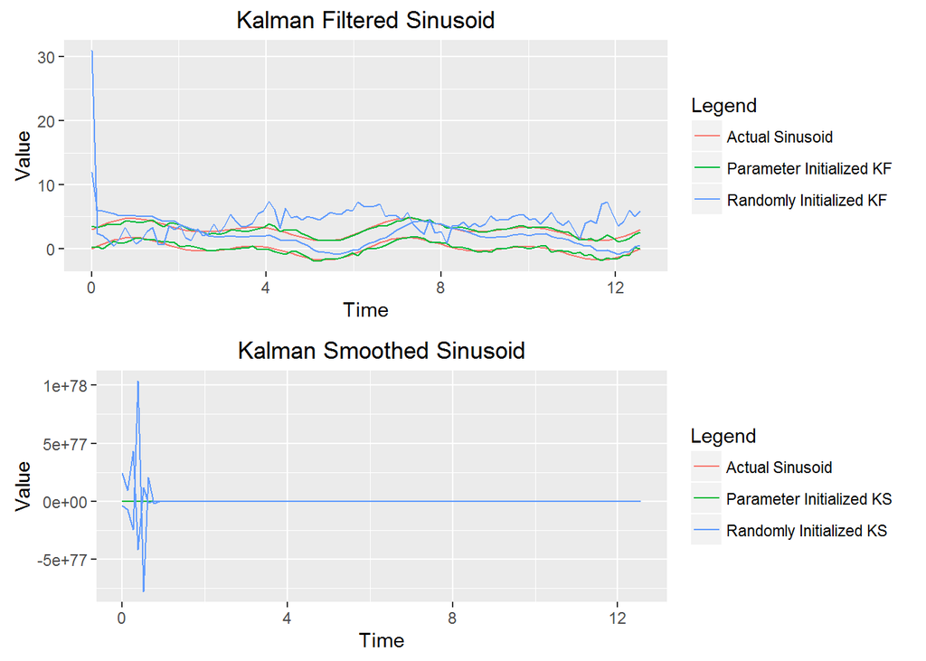

```
## [1] "Measurement R^2:  0.76672 0.74508"
## [1] "Kalman Filter R^2:  0.88899 0.86477  vs.  0.03708 0.54016"
## [1] "Kalman Smoother R^2:  0.94583 0.94561  vs.  8e-05 0.00012"
```

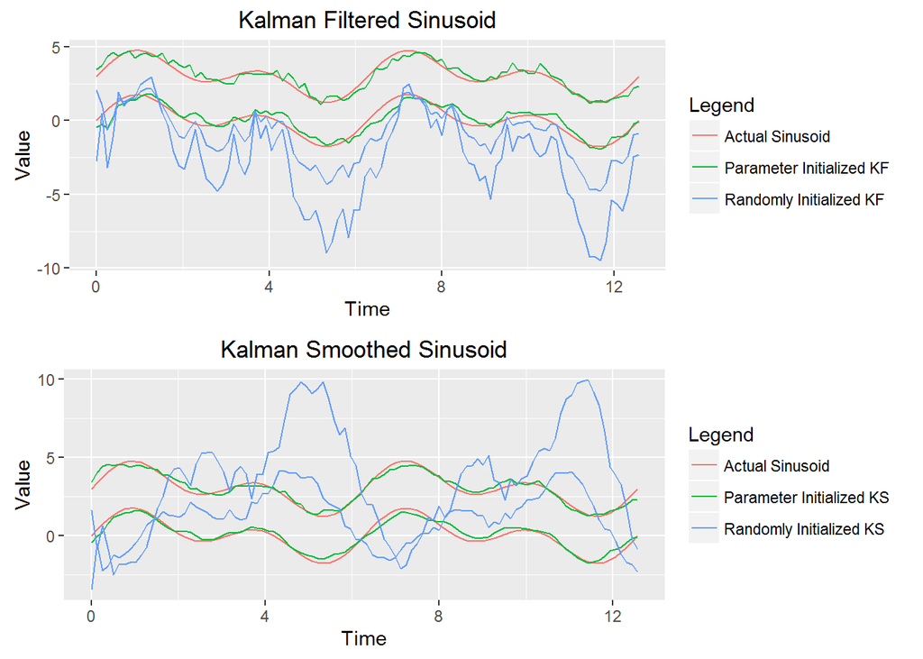

```
## [1] "Measurement R^2:  0.78967 0.78675"
## [1] "Kalman Filter R^2:  0.83665 0.88793  vs.  0.82862 0.82238"
## [1] "Kalman Smoother R^2:  0.94749 0.94227  vs.  0.76395 0.25706"
```

```r
t <- seq(0,4*pi,,100)

actual1 <- sin(t) + sin(2*t)
actual2 <- sin(t) + sin(2*t) + 3
actual = array(actual1, dim=c(100,2))
actual[,2] <- actual2

for(i in 1:10) {
  meas1 <- actual1 + rnorm(100, mean=0, sd=0.5)
  meas2 <- actual2 + rnorm(100, mean=0, sd=0.5)
  meas = array(meas1, dim=c(100,2))
  meas[,2] <- meas2

  par = KFS_init(t(meas))
  x = KFS(par$A, par$C, par$Q, par$R, par$x0, par$v0, y=t(meas))

  A = array(runif(4, 0, 1), dim=c(2,2))
  C = array(runif(4, 0, 1), dim=c(2,2))
  Q = array(runif(4, 0, 1), dim=c(2,2))
  R = array(runif(4, 0, 1), dim=c(2,2))
  x0 = array(c(runif(1, -1, 1), 3 + runif(1, -1, 1)), dim=c(2,1))
  v0 = array(runif(4, -1, 1), dim=c(2,2))
  z = KFS(A, C, Q, R, x0, v0, y=t(meas))

  kf_data <-
  data.frame(
    ac1 = actual[,1],
    ac2 = actual[,2],
    kx1 = x$Fx1[1,],
    kx2 = x$Fx1[2,],
    kz1 = z$Fx1[1,],
    kz2 = z$Fx1[2,],
    time = t
  )

  ks_data <-
  data.frame(
    ac1 = actual[,1],
    ac2 = actual[,2],
    kx1 = x$Sx[1,],
    kx2 = x$Sx[2,],
    kz1 = z$Sx[1,],
    kz2 = z$Sx[2,],
    time = t
  )

  #Plot
  fplot <- ggplot(kf_data, aes(time, colour=Legend)) + geom_line(aes(y=ac1, color="Actual Sinusoid"))+ geom_line(aes(y=ac2, color="Actual Sinusoid")) + geom_line(aes(y=kx1, color="Parameter Initialized KF")) + geom_line(aes(y=kx2, color="Parameter Initialized KF")) + geom_line(aes(y=kz1, color="Randomly Initialized KF")) + geom_line(aes(y=kz2, color="Randomly Initialized KF")) + labs(x="Time", y="Value", title="Kalman Filtered Sinusoid")
  splot <- ggplot(ks_data, aes(time, colour=Legend)) + geom_line(aes(y=ac1, color="Actual Sinusoid"))+ geom_line(aes(y=ac2, color="Actual Sinusoid")) + geom_line(aes(y=kx1, color="Parameter Initialized KS")) + geom_line(aes(y=kx2, color="Parameter Initialized KS")) + geom_line(aes(y=kz1, color="Randomly Initialized KS")) + geom_line(aes(y=kz2, color="Randomly Initialized KS")) + labs(x="Time", y="Value", title="Kalman Smoothed Sinusoid")
  multiplot(fplot, splot)

  ms1r2 = sum((cor(actual[,1], meas[,1]))^2)
  ms2r2 = sum((cor(actual[,2], meas[,2]))^2)
  xf1r2 = sum((cor(actual[,1], x$Fx1[1,]))^2)
  xf2r2 = sum((cor(actual[,2], x$Fx1[2,]))^2)
  xs1r2 = sum((cor(actual[,1], x$Sx[1,]))^2)
  xs2r2 = sum((cor(actual[,2], x$Sx[2,]))^2)
  zf1r2 = sum((cor(actual[,1], z$Fx1[1,]))^2)
  zf2r2 = sum((cor(actual[,2], z$Fx1[2,]))^2)
  zs1r2 = sum((cor(actual[,1], z$Sx[1,]))^2)
  zs2r2 = sum((cor(actual[,2], z$Sx[2,]))^2)
  print(paste("Measurement R^2: ", round(ms1r2, digits=5), round(ms2r2, digits=5)))
  print(paste("Kalman Filter R^2: ", round(xf1r2, digits=5), round(xf2r2, digits=5), " vs. ", round(zf1r2, digits=5), round(zf2r2, digits=5)))
  print(paste("Kalman Smoother R^2: ", round(xs1r2, digits=5), round(xs2r2, digits=5), " vs. ", round(zs1r2, digits=5), round(zs2r2, digits=5)))
}
```


### Sim. 2

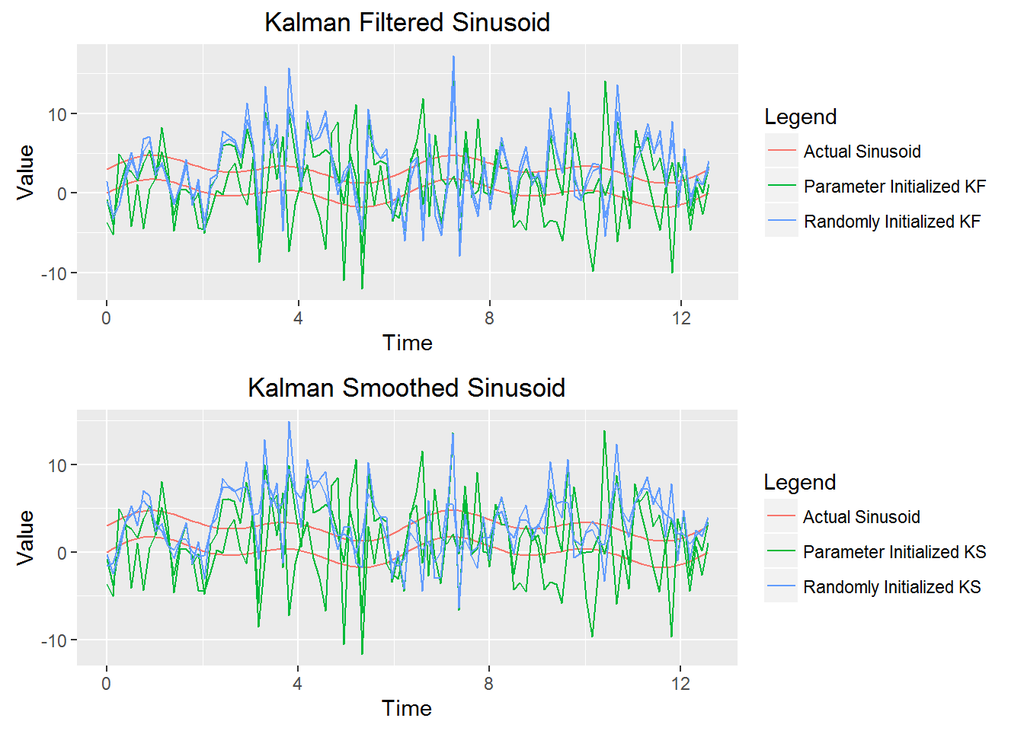

```
## [1] "Measurement R^2:  0.01912 0.00225"
## [1] "Kalman Filter R^2:  0.02001 0.00249  vs.  0.0201 0.01401"
## [1] "Kalman Smoother R^2:  0.02102 0.00261  vs.  0.03852 0.01924"
```

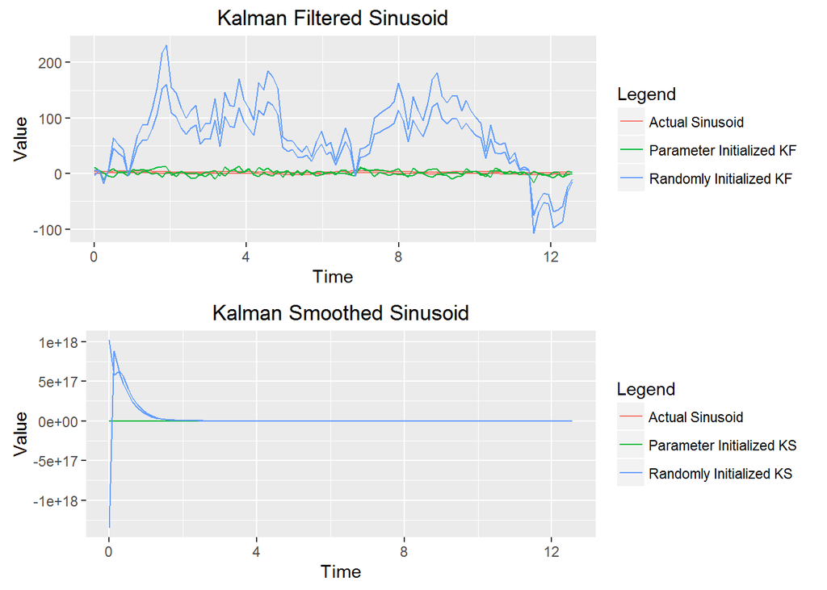

```
## [1] "Measurement R^2:  0.00998 0.11338"
## [1] "Kalman Filter R^2:  0.01054 0.11755  vs.  0.06739 0.06565"
## [1] "Kalman Smoother R^2:  0.01124 0.1232  vs.  0.03941 0.03292"
```

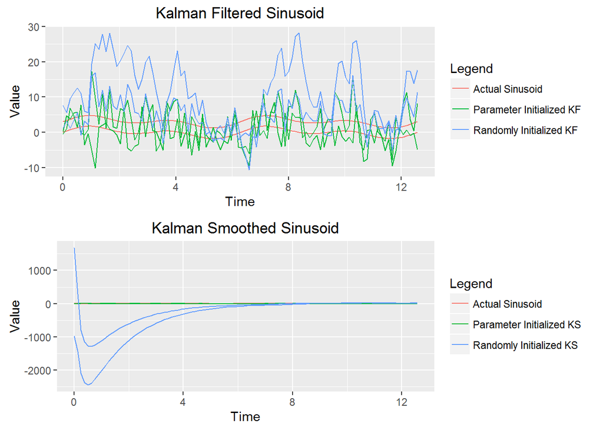

```
## [1] "Measurement R^2:  0.0414 0.09291"
## [1] "Kalman Filter R^2:  0.04442 0.09669  vs.  0.08528 0.1517"
## [1] "Kalman Smoother R^2:  0.04754 0.10121  vs.  0.23722 0.17806"
```

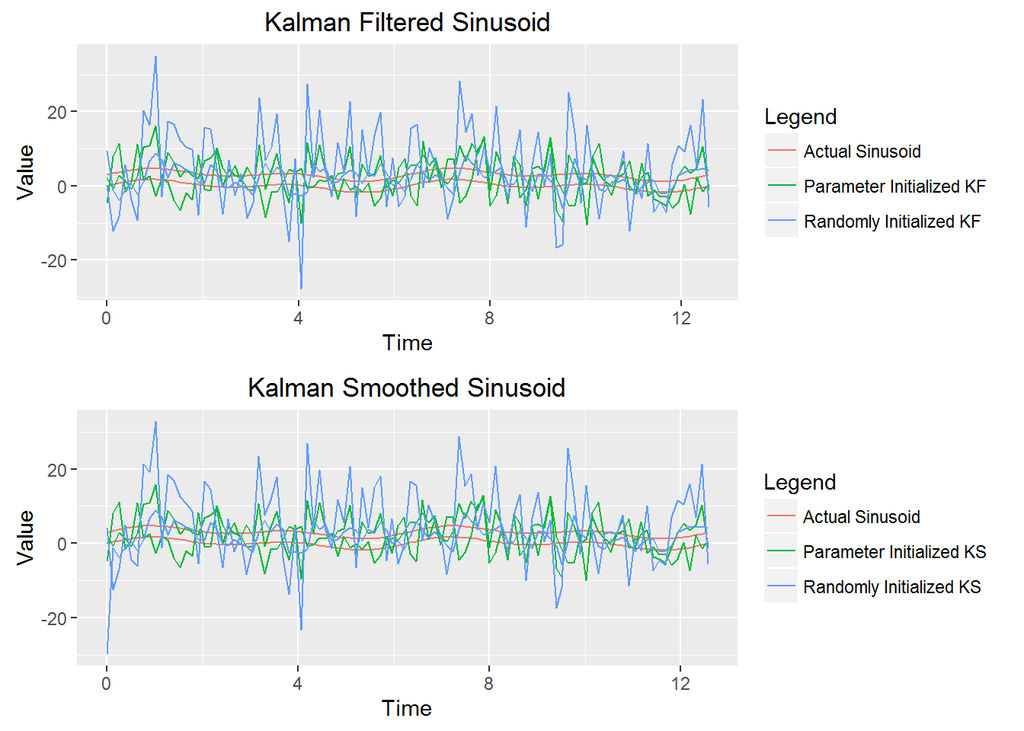

```
## [1] "Measurement R^2:  0.03787 0.0758"
## [1] "Kalman Filter R^2:  0.03978 0.07938  vs.  0.01519 0.02678"
## [1] "Kalman Smoother R^2:  0.04165 0.08339  vs.  0.01941 0.01317"
```

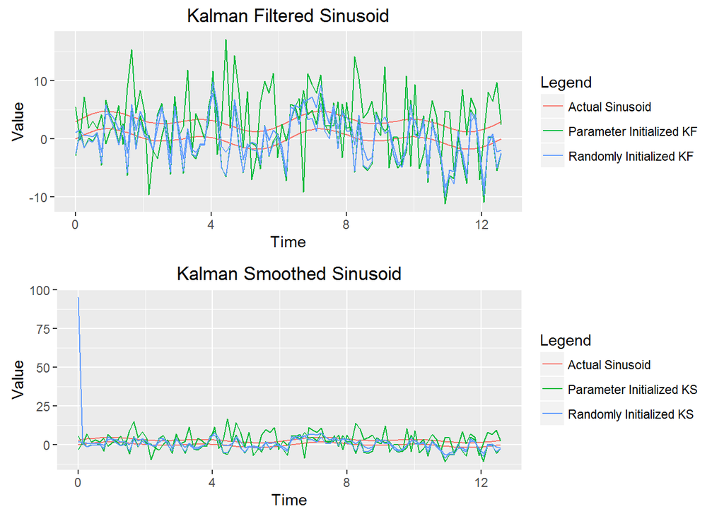

```
## [1] "Measurement R^2:  0.12858 0.00256"
## [1] "Kalman Filter R^2:  0.13673 0.00265  vs.  0.11326 0.22478"
## [1] "Kalman Smoother R^2:  0.14465 0.00277  vs.  0.01549 0.30528"
```

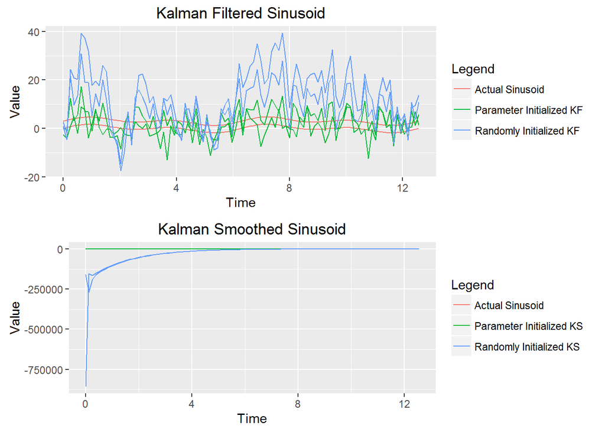

```
## [1] "Measurement R^2:  0.03613 0.08923"
## [1] "Kalman Filter R^2:  0.03838 0.09356  vs.  0.30545 0.19799"
## [1] "Kalman Smoother R^2:  0.04016 0.09707  vs.  0.15448 0.0368"
```

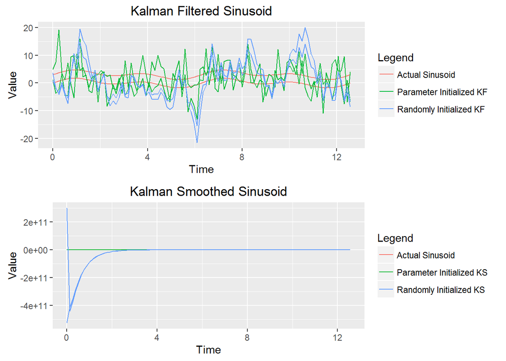

```
## [1] "Measurement R^2:  0.08685 0.0326"
## [1] "Kalman Filter R^2:  0.09008 0.03446  vs.  0.15265 0.14945"
## [1] "Kalman Smoother R^2:  0.09395 0.03606  vs.  0.06673 0.08303"
```

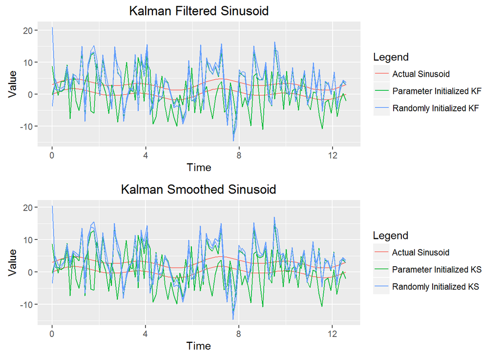

```
## [1] "Measurement R^2:  0.04984 0.02865"
## [1] "Kalman Filter R^2:  0.05206 0.02971  vs.  0.0627 0.03026"
## [1] "Kalman Smoother R^2:  0.0541 0.03072  vs.  0.07494 0.04037"
```

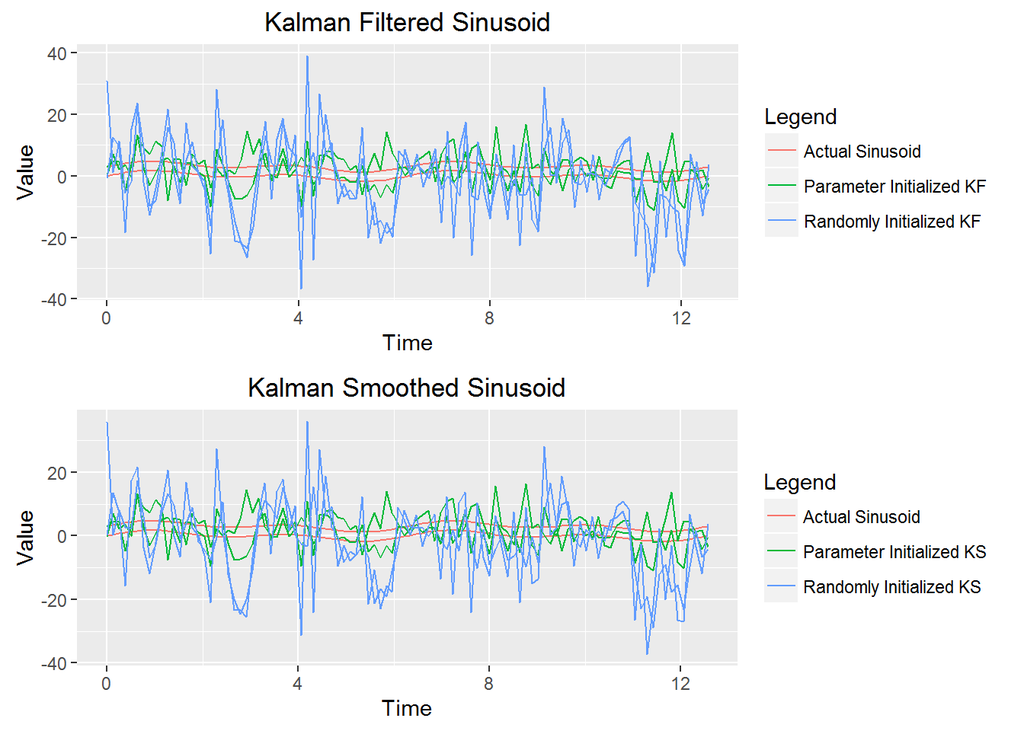

```
## [1] "Measurement R^2:  0.1118 0.0255"
## [1] "Kalman Filter R^2:  0.11677 0.02702  vs.  0.12003 0.06683"
## [1] "Kalman Smoother R^2:  0.12204 0.02818  vs.  0.20811 0.08814"
```

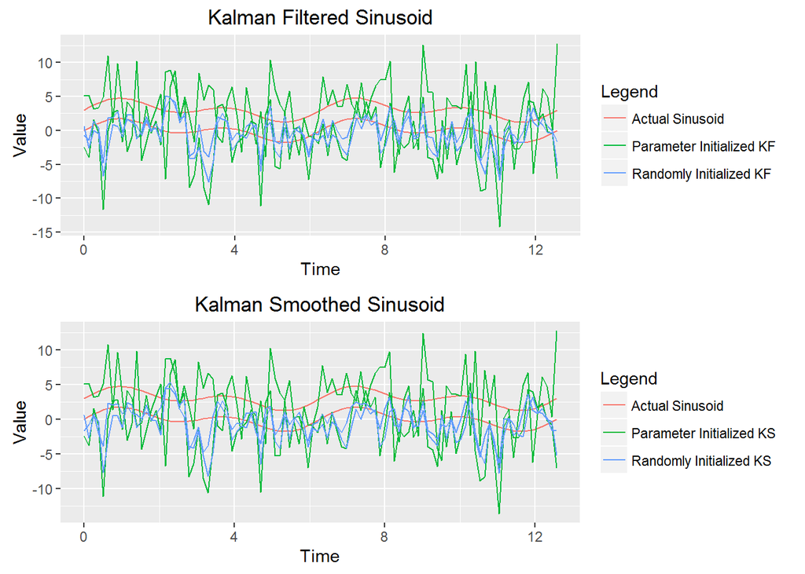

```
## [1] "Measurement R^2:  0.01119 0.03704"
## [1] "Kalman Filter R^2:  0.01181 0.03934  vs.  0.00544 0.02822"
## [1] "Kalman Smoother R^2:  0.01281 0.04115  vs.  0.00189 0.04052"
```

```r
t <- seq(0,4*pi,,100)

actual1 <- sin(t) + sin(2*t)
actual2 <- sin(t) + sin(2*t) + 3
actual = array(actual1, dim=c(100,2))
actual[,2] <- actual2

for(i in 1:10) {
  meas1 <- actual1 + rnorm(100, mean=0, sd=5)
  meas2 <- actual2 + rnorm(100, mean=0, sd=5)
  meas = array(meas1, dim=c(100,2))
  meas[,2] <- meas2

  par = KFS_init(t(meas))
  x = KFS(par$A, par$C, par$Q, par$R, par$x0, par$v0, y=t(meas))

  A = array(runif(4, 0, 1), dim=c(2,2))
  C = array(runif(4, 0, 1), dim=c(2,2))
  Q = array(runif(4, 0, 1), dim=c(2,2))
  R = array(runif(4, 0, 1), dim=c(2,2))
  x0 = array(c(runif(1, -1, 1), 3 + runif(1, -1, 1)), dim=c(2,1))
  v0 = array(runif(4, -1, 1), dim=c(2,2))
  z = KFS(A, C, Q, R, x0, v0, y=t(meas))

  kf_data <-
  data.frame(
    ac1 = actual[,1],
    ac2 = actual[,2],
    kx1 = x$Fx1[1,],
    kx2 = x$Fx1[2,],
    kz1 = z$Fx1[1,],
    kz2 = z$Fx1[2,],
    time = t
  )

  ks_data <-
  data.frame(
    ac1 = actual[,1],
    ac2 = actual[,2],
    kx1 = x$Sx[1,],
    kx2 = x$Sx[2,],
    kz1 = z$Sx[1,],
    kz2 = z$Sx[2,],
    time = t
  )

  #Plot
  fplot <- ggplot(kf_data, aes(time, colour=Legend)) + geom_line(aes(y=ac1, color="Actual Sinusoid"))+ geom_line(aes(y=ac2, color="Actual Sinusoid")) + geom_line(aes(y=kx1, color="Parameter Initialized KF")) + geom_line(aes(y=kx2, color="Parameter Initialized KF")) + geom_line(aes(y=kz1, color="Randomly Initialized KF")) + geom_line(aes(y=kz2, color="Randomly Initialized KF")) + labs(x="Time", y="Value", title="Kalman Filtered Sinusoid")
  splot <- ggplot(ks_data, aes(time, colour=Legend)) + geom_line(aes(y=ac1, color="Actual Sinusoid"))+ geom_line(aes(y=ac2, color="Actual Sinusoid")) + geom_line(aes(y=kx1, color="Parameter Initialized KS")) + geom_line(aes(y=kx2, color="Parameter Initialized KS")) + geom_line(aes(y=kz1, color="Randomly Initialized KS")) + geom_line(aes(y=kz2, color="Randomly Initialized KS")) + labs(x="Time", y="Value", title="Kalman Smoothed Sinusoid")
  multiplot(fplot, splot)

  ms1r2 = sum((cor(actual[,1], meas[,1]))^2)
  ms2r2 = sum((cor(actual[,2], meas[,2]))^2)
  xf1r2 = sum((cor(actual[,1], x$Fx1[1,]))^2)
  xf2r2 = sum((cor(actual[,2], x$Fx1[2,]))^2)
  xs1r2 = sum((cor(actual[,1], x$Sx[1,]))^2)
  xs2r2 = sum((cor(actual[,2], x$Sx[2,]))^2)
  zf1r2 = sum((cor(actual[,1], z$Fx1[1,]))^2)
  zf2r2 = sum((cor(actual[,2], z$Fx1[2,]))^2)
  zs1r2 = sum((cor(actual[,1], z$Sx[1,]))^2)
  zs2r2 = sum((cor(actual[,2], z$Sx[2,]))^2)
  print(paste("Measurement R^2: ", round(ms1r2, digits=5), round(ms2r2, digits=5)))
  print(paste("Kalman Filter R^2: ", round(xf1r2, digits=5), round(xf2r2, digits=5), " vs. ", round(zf1r2, digits=5), round(zf2r2, digits=5)))
  print(paste("Kalman Smoother R^2: ", round(xs1r2, digits=5), round(xs2r2, digits=5), " vs. ", round(zs1r2, digits=5), round(zs2r2, digits=5)))
}
```

We can see that now that there is more uncertainty in the measured values, the parameter initialized KFS $R^2$ values are often not higher than the randomly initialized KFS $R^2$ values.

## Final Comments

The parameter initialization method works fairly well and is decently resilient. Its one downside however, is apparent when there is a very noisy measurement. In these situations, the model does poorly at predicting the errors and therefore does not lead to the desired smoothed curve, often being beat by the randomly initialized KFS.